# Offensive Position and Age at First Recorded NFL Head Injury

Comparing means, ranks, and the assumptions behind them

Football

ANOVA

Kruskal-Wallis

Multiple Comparisons

Use NFL injury records to explore one-way ANOVA, Tukey comparisons, Welch ANOVA, and Kruskal–Wallis.

Authors

Affiliation

Hailey Collins

Baylor University

Joshua Patrick

Baylor University

Published

July 23, 2026

# Introduction

Do offensive football positions differ in the ages of players appearing in head injury records? In this module, we use public NFL records to compare four position groups and examine how our conclusions depend on the question, the inclusion rules, and the statistical method.

Our response is **approximate age at a player’s first qualifying injury record within this dataset**. We calculate age at the game date associated with that record. This is not necessarily the player’s first career injury or the exact date of injury. Earlier injuries outside the observation window are unavailable. The dataset also lacks an uninjured comparison group and complete exposure data for all players, so this analysis cannot estimate concussion risk by position.

[figure not shown]

Football Concussions

**NoteBefore you begin**

**Audience:** Students in an introductory statistics course who have encountered hypothesis tests and confidence intervals.

**Prerequisites:** Means, standard deviations, boxplots, p-values, and basic R syntax. The preparation code is supplied; data wrangling is not a prerequisite.

**Suggested time:** 75–90 minutes for the core activity, plus 30–45 minutes for the optional season extension and sensitivity exercise.

**NoteLearning objectives**

By the end of this module, you will be able to:

- Define the observational unit and distinguish recorded injury age from injury risk.
- Use summaries and diagnostic plots to assess whether a one-way ANOVA model is reasonable.
- Run and interpret ANOVA and Tukey pairwise comparisons in R.
- Explain how Welch ANOVA and Kruskal–Wallis address different questions or assumptions.
- Interpret Holm-adjusted pairwise Wilcoxon comparisons.
- Describe how inclusion decisions and sampling limitations affect conclusions.

# Context and research question

A concussion is a traumatic brain injury that can affect brain function ([Mayo Clinic](https://www.mayoclinic.org/diseases-conditions/concussion/symptoms-causes/syc-20355594)). Research in **NCAA Division I football players** has examined differences in head-impact-related outcomes by position; that study provides background, rather than direct evidence about the NFL sample used here ([Baugh et al., 2015](https://pmc.ncbi.nlm.nih.gov/articles/PMC4628259/)).

Our primary question is:

> Among included players whose first qualifying record occurred in 2012/2013, does mean age at that record differ across offensive position groups?

We use the following categories, based on the position listed on the selected record:

| Group | Positions included |
| --- | --- |
| QB | Quarterback |
| RB | Running back and fullback |
| Receiver | Wide receiver and tight end |
| Offensive Line (OL) | Offensive tackle, guard, and center |

These combined groups keep the introductory comparison manageable. They still contain players with different roles. Long snappers are excluded as special teams players, rather than combined with offensive linemen. A listed position does not identify what the player was doing when the injury occurred, and the source’s position classifications have not been independently verified.

# Data and inclusion rules

The files come from the public [`ali-ce/datasets` NFL folder](https://github.com/ali-ce/datasets/tree/bab356b2590cbc1f600054f0584509beb2af272d/NFL). The event file has 392 rows, and the player file has 343 unique player names. The module uses a fixed repository version so that later source changes do not silently alter the analysis.

We treat the files as a compiled classroom dataset. Its available fields do not establish complete surveillance or independently verified clinical diagnoses. In particular, the label `Head` is broader than a confirmed concussion. A record flagged as not unknown is still only a classification supplied by the source.

The primary analysis follows these rules in order:

1. Keep event records labeled `Head` or `Concussion`.
2. Exclude records flagged as unknown and records flagged as preseason injuries. Preseason flags matter because a record’s listed game date may differ from the date of a preseason injury.
3. Select each player’s earliest remaining record across the entire observation window. This happens before dividing the data by season.
4. Join the date of birth by player name and calculate approximate age as the number of days from birth to the associated game date divided by 365.25.
5. Keep players in the four offensive groups, then select the analysis season.

We recalculate age rather than reuse `Age first concussion (2012-2014)`: changing the eligible events could change which record is first. These operational rules are used consistently throughout the module.

The processed data are available in the files `offense_2012.csv` and `offense_2013.csv`

Table 1: Sequential preparation counts. The unit changes from events to players after selecting the first qualifying record.

| Stage | Unit | Count |
| --- | --- | --- |
| All source event records | Events | 392 |
| Labeled Head or Concussion | Events | 388 |
| Also not flagged as unknown | Events | 384 |
| Also not flagged as preseason | Events | 358 |
| First qualifying record per player | Players | 315 |
| Players in the four offensive groups | Players | 163 |
| Primary analysis: first qualifying record in 2012/2013 | Players | 83 |

**NoteWhat do the variables mean?**

| Variable | Meaning and use |
| --- | --- |
| `Player` | Source player name; the join key and observational unit after preparation. |
| `Date` / `record_date` | Source game-associated date, parsed as day/month/year. It is not independently verified as the injury date. |
| `Season` | Source season label; for example, `2012/2013`. |
| `Position` | Position listed on the selected event record. |
| `Reported Injury Type` | Source injury classification; eligibility is restricted to `Head` or `Concussion`. |
| `Unknown Injury?` | Source uncertainty flag; primary analysis requires `No`. |
| `Pre-Season Injury?` | Source preseason flag; primary analysis requires `No`. |
| `Date of Birth` / `birth_date` | Source date of birth, parsed as day/month/year. |
| `age` | Derived approximate age in years at the selected record’s associated game date. |
| `position_group` | Derived offensive position category. |

The source provides player biography links, but its files do not fully document the original injury collection and verification process. Retain this limitation when reporting results; do not describe the files as an official NFL registry.

The join checks confirm unique names in the player file, no unmatched event players, valid dates, and one selected record per player. Name-based matching can still fail to distinguish different people with identical names. No statistical test can establish that the source identities or dates are correct.

**NoteInspect the preparation in R**

The complete preparation is in this QMD’s setup chunk. Its essential sequence is:

```r
eligible_events <- events |>
  filter(
    `Reported Injury Type` %in% c("Head", "Concussion"),
    `Unknown Injury?` == "No",
    `Pre-Season Injury?` == "No"
  )

# select_first() sorts eligible dates, keeps one record per player,
# joins birth dates, recalculates age, and assigns position groups.
first_eligible <- select_first(eligible_events)
offense <- first_eligible |> filter(!is.na(position_group))
offense_2012 <- offense |> filter(Season == "2012/2013")
```

# Part 1: Explore the 2012/2013 data

Each observation below represents one included player. Age is displayed to two decimal places for comparison; this formatting does not imply that the injury date is known precisely.

Table 2: Approximate age in years at the first qualifying record, 2012/2013.

| Position group | Players | Mean | Median | SD | Min | Max |
| --- | --- | --- | --- | --- | --- | --- |
| QB | 6 | 28.68 | 29.33 | 3.30 | 22.65 | 32.38 |
| RB | 16 | 25.57 | 24.69 | 2.42 | 22.37 | 31.72 |
| Receiver | 43 | 26.69 | 26.51 | 2.27 | 23.04 | 33.43 |
| Offensive Line | 18 | 27.25 | 27.48 | 2.28 | 22.81 | 31.00 |

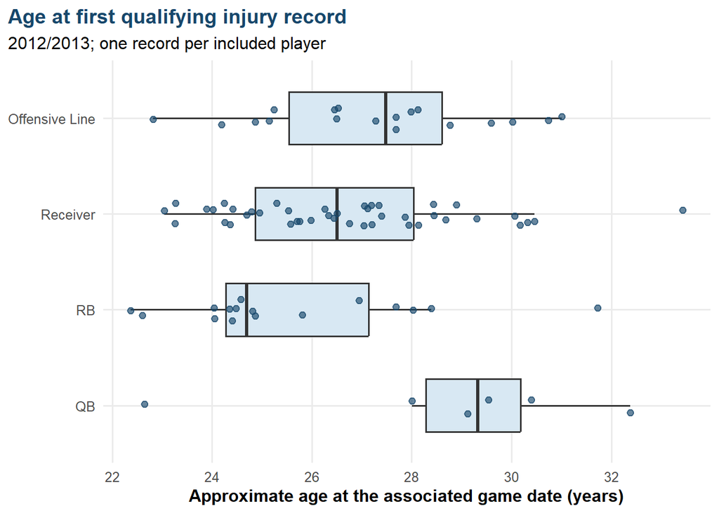

Figure 1: Boxplots with all individual player ages. Horizontal positions show age; small vertical offsets separate overlapping points.

**NoteThink before testing**

Record your answers before continuing:

1. Which group has the highest mean age? Which has the lowest?
2. How do the sample sizes and standard deviations compare?
3. Which observations warrant closer examination? Does an unusual age imply an error?
4. What information about the uninjured NFL population would help interpret these differences?

# Part 2: One-way ANOVA and model checks

One-way **analysis of variance (ANOVA)** compares population means across groups. Here, the explanatory variable is position group and the quantitative response is approximate age at the selected record.

For $k = 4$ groups, the hypotheses are:

$$\begin{align*}
&H_0: \mu_{\mathrm{OL}} = \mu_{\mathrm{QB}} =
\mu_{\mathrm{RB}} = \mu_{\mathrm{Receiver}}\\
&H_A: \text{Not all population means are equal.}
\end{align*}$$

The population is conceptual: comparable players represented by this recording process and these inclusion rules. This is not a random sample of all NFL players. Inferential results are model-based classroom illustrations, and their generalizability depends on assumptions the files cannot verify. Set $\alpha = 0.05$ before examining the tests.

## Fit the model, then assess it before interpreting it

```r
library(tidyverse)
offense_2012 <- read_csv("offense_2012.csv")
anova_2012 <- aov(age ~ position_group, data = offense_2012)
```

The classical ANOVA model assumes independent errors, approximately normal error distributions within groups, and equal population error variances. The categorical explanatory variable and quantitative response describe the model’s setup.

- **Independence:** Selecting one record per player avoids treating repeat injuries from the same player as separate independent observations. It does not rule out dependence involving teammates, shared games, or reporting practices. Assess independence from the study design, not from the following plots.
- **Normality:** Examine residuals and group distributions for strong departures from the model. A boxplot flag is a prompt to investigate, not proof that ANOVA is invalid. Small groups give limited information about distribution shape.
- **Equal variances:** Compare group spreads, considering unequal sample sizes. The smallest group can make this assumption especially consequential.

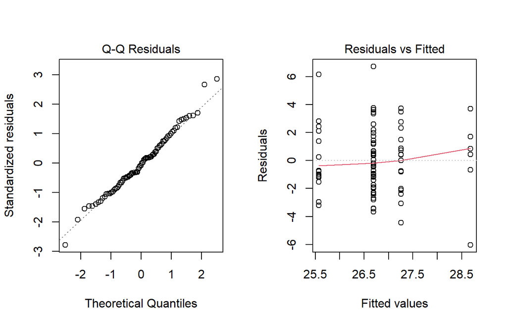

Figure 2: Residual Q–Q plot and residuals versus fitted group means for the classical ANOVA model.

```r
old_par <- par(mfrow = c(1, 2))
plot(anova_2012, which = 2, id.n = 0)
plot(anova_2012, which = 1, id.n = 0)
par(old_par)
```

The fitted values are group means, so the second plot has four vertical bands. Look for differences in vertical spread. The QQ plot checks the pooled residual pattern; revisit the individual group plot because a pooled plot can hide group differences.

In this sample, quarterbacks contribute only 6 observations, compared with 43 receivers. The ratio of the largest to smallest sample SD is 1.45. This is descriptive evidence, not a pass/fail cutoff. In particular, six quarterback ages cannot establish that the group’s underlying distribution is normal.

**NoteDiagnostic checkpoint**

Describe one feature that supports the model and one feature that deserves caution. Which assumptions can these plots help assess, and which require information about how the records were collected?

Do not use a normality test as an automatic switch between methods: a large p-value does not verify normality, especially with a small group.

## Read the ANOVA results

```r
anova_terms <- tidy(anova_2012)
summary(anova_2012)
```

```
               Df Sum Sq Mean Sq F value Pr(>F)
position_group  3   49.3   16.44   2.899 0.0402 *
Residuals      79  447.9    5.67
---
Signif. codes:  0 '***' 0.001 '**' 0.01 '*' 0.05 '.' 0.1 ' ' 1
```

Table 3: Classical one-way ANOVA for the primary 2012/2013 sample.

| Source | df | Sum of squares | Mean square | F | p-value |
| --- | --- | --- | --- | --- | --- |
| Position group | 3 | 49.309 | 16.436 | 2.899 | 0.0402 |
| Residuals | 79 | 447.923 | 5.670 | — | — |

The F-statistic compares between-group and within-group mean squares:

$$F = \frac{MS_{\text{Between}}}{MS_{\text{Within}}}
= \frac{16.436}{5.670}
= 2.899.$$

The result is $F(3, 79) = 2.899$, with $p = 0.0402$. At the chosen threshold, we reject the equal-means null hypothesis. The p-value is the probability, assuming the null hypothesis and model assumptions, of an F-statistic at least as large as the one observed. It is not the probability that the null hypothesis is true.

**NoteHow is F calculated?**

For $k$ groups with total sample size $N$,

$$MS_{\text{Between}} =
\frac{\sum_{j=1}^{k} n_j(\bar X_j-\bar X_G)^2}{k-1},$$

$$MS_{\text{Within}} =
\frac{\sum_{j=1}^{k}\sum_{i=1}^{n_j}(X_{ij}-\bar X_j)^2}{N-k}.$$

Here, $n_j$ is the number of observations in group $j$, $\bar X_j$ is its mean, $\bar X_G$ is the grand mean, and $X_{ij}$ is observation $i$ in group $j$. When the denominator is positive, F is nonnegative and can be zero if all sample means coincide. A large F indicates greater separation relative to within-group variation; its evidential meaning depends on its reference distribution and degrees of freedom.

# Part 3: Tukey pairwise comparisons

ANOVA addresses whether all means are equal; it does not identify particular pairs. **Tukey’s HSD**, with the unequal-sample-size adjustment implemented in R, compares all pairs using the classical model’s pooled variance. The intervals are approximate simultaneous 95% confidence intervals for the family of six comparisons with these unequal group sizes, subject to the model assumptions.

```r
tukey_2012 <- TukeyHSD(anova_2012, conf.level = 0.95)
tukey_table <- tidy(tukey_2012) |>
  select(contrast, estimate, conf.low, conf.high, adj.p.value)
```

Table 4: Tukey comparisons. Each estimate is the first named group’s mean minus the second named group’s mean, in years.

| Comparison | Difference (years) | Lower simultaneous 95% CI | Upper simultaneous 95% CI | Adjusted p-value |
| --- | --- | --- | --- | --- |
| QB-Offensive Line | 1.43 | −1.52 | 4.37 | 0.5844 |
| RB-Offensive Line | −1.68 | −3.83 | 0.46 | 0.1762 |
| Receiver-Offensive Line | −0.56 | −2.32 | 1.19 | 0.8350 |
| RB-QB | −3.11 | −6.10 | −0.12 | 0.0385 |
| Receiver-QB | −1.99 | −4.71 | 0.74 | 0.2299 |
| Receiver-RB | 1.12 | −0.71 | 2.95 | 0.3800 |

For `RB-QB`, the estimated difference is -3.11 years, with simultaneous 95% interval (-6.10, -0.12) and adjusted $p = 0.0385$. Equivalently, the sample mean for quarterbacks is 3.11 years higher than for running backs. Reversing the comparison gives interval (0.12, 6.10) years.

**NoteCheck your interpretation**

Why does a negative `RB-QB` estimate correspond to older quarterbacks? Which intervals include zero? Explain why an interval that includes zero does not establish that the two population means are identical.

# Part 4: Alternative methods and their questions

## Welch ANOVA: keep the question about means

If equal variances are questionable, **Welch ANOVA** compares means without assuming equal population variances. It still requires independent observations and appropriate distributional conditions; it is not a remedy for every model problem. R implements it with `oneway.test()`.

```r
welch_2012 <- oneway.test(
  age ~ position_group, data = offense_2012, var.equal = FALSE
)
welch_2012
```

```
    One-way analysis of means (not assuming equal variances)

data:  age and position_group
F = 2.0841, num df = 3.000, denom df = 18.521, p-value = 0.1371
```

Welch’s test gives $F = 2.084$ with approximately 18.52 denominator degrees of freedom and $p = 0.1371$. Compare this with the classical ANOVA result. Different handling of variance and uncertainty can matter when sample sizes are small and unequal. Report that sensitivity rather than selecting whichever method gives a preferred significance decision.

If Welch ANOVA is used as the primary model, its pairwise follow-up should also allow unequal variances, for example Games–Howell comparisons.

## Kruskal–Wallis: compare ranks

The **Kruskal–Wallis test** pools and ranks the observations, then compares rank patterns across groups. It can be useful for ordinal responses or when strong distributional concerns motivate a rank-based question. It requires independent observations and is not assumption-free.

For this module, state the hypotheses as:

$$\begin{align*}
&H_0: \text{The age distributions are identical across the four groups.}\\
&H_A: \text{The groups differ in their age distributions, as reflected in ranks.}
\end{align*}$$

Kruskal–Wallis is particularly useful for location differences. With comparable distribution shapes and spreads, it can be interpreted as a comparison of locations, including medians. Without those conditions, do not describe it simply as a test of equal medians: differing shapes or spreads can affect rank patterns, and it does not detect every possible distributional difference.

```r
kruskal_2012 <- kruskal.test(age ~ position_group, data = offense_2012)
kruskal_2012
```

```
    Kruskal-Wallis rank sum test

data:  age by position_group
Kruskal-Wallis chi-squared = 8.5226, df = 3, p-value = 0.03636
```

The test gives $H = 8.523$ with 3 degrees of freedom and $p = 0.0364$. R uses an approximate chi-squared reference distribution with a correction for ties.

Table 5: Three methods applied to the same primary 2012/2013 sample. Their assumptions and targets differ.

| Method | Target | p-value | Decision at 0.05 |
| --- | --- | --- | --- |
| Classical ANOVA | Group means; equal variances | 0.0402 | Reject H0 |
| Welch ANOVA | Group means; unequal variances allowed | 0.1371 | Do not reject H0 |
| Kruskal–Wallis | Group rank patterns | 0.0364 | Reject H0 |

**TipWhat should we conclude?**

Under the primary inclusion rules, classical ANOVA and Kruskal–Wallis both give p-values below 0.05, while Welch ANOVA does not. These results show sensitivity to method; they do not prove that one test is correct or that another is wrong. The tests use different assumptions, and the rank-based test changes the target of inference.

The most defensible report combines the observed age differences, their uncertainty, the small and unequal group sizes, and the dataset’s limitations. A p-value just above 0.05 does not establish equality, and one just below 0.05 does not establish a large or practically important effect.

# Part 5: Rank-based pairwise comparisons

To practice pairwise rank-based inference, use **Wilcoxon rank-sum tests** with a **Holm adjustment** across the six pairs. Holm’s method controls the family-wise error rate when the individual tests provide valid p-values. It does not adjust for every analysis or inclusion rule explored elsewhere in the module.

```r
wilcoxon_2012 <- pairwise.wilcox.test(
  offense_2012$age, offense_2012$position_group,
  p.adjust.method = "holm", exact = FALSE
)
```

Here, `exact = FALSE` explicitly requests the normal approximation; the default continuity correction is retained. Ages can be tied. Approximation quality is also relevant for the small quarterback group. The Wilcoxon tests compare rank patterns, not mean differences; location or median interpretations require additional distributional assumptions.

Table 6: Pairwise Wilcoxon rank-sum comparisons, with Holm adjustment across six pairs.

| Group | Compared with | Holm-adjusted p-value |
| --- | --- | --- |
| QB | Offensive Line | 0.3872 |
| RB | Offensive Line | 0.1944 |
| RB | QB | 0.2131 |
| Receiver | Offensive Line | 0.3872 |
| Receiver | QB | 0.2600 |
| Receiver | RB | 0.2600 |

The smallest adjusted p-value is 0.1944. No pair is significant at 0.05 under this procedure. An global test and adjusted pairwise tests can reach different decisions: they ask different questions and use different rejection rules. An global rejection does not guarantee that this particular pairwise procedure will identify a significant pair.

**NoteWhy not Dunn’s test?**

Dunn’s test is another common follow-up to Kruskal–Wallis. It retains the ranks from the pooled sample; pairwise Wilcoxon tests rerank observations separately within each pair. They are related approaches, not identical procedures. We use pairwise Wilcoxon here because it is available in base R and illustrates multiple-comparison adjustment without adding another package.

# Your turn: the 2013/2014 cohort

Repeat the analysis for included players whose **first qualifying record in the entire dataset** occurs in 2013/2014. Players already represented in 2012/2013 cannot enter this cohort, even if they later have another injury. It is not a sample of all injured players in the later season.

**NoteHistorical context and coverage**

A 2013 rule restricted crown-of-helmet contact outside the tackle box ([NFL rule timeline](https://www.nfl.com/playerhealthandsafety/equipment-and-innovation/rules-changes/nfl-health-and-safety-related-rules-changes-since-2002)). This provides background for separate season descriptions, not a design for estimating a rule effect. Roster composition, reporting, exposure, and cohort selection may also vary. Different significance decisions across seasons do not establish a change in the position–age relationship; that would require a direct comparison and additional assumptions. Neither analysis estimates a causal rule effect.

The source’s available dates are shown below. The 2014/2015 data end in November 2014 and are not a full season. The module therefore uses 2013/2014 for its guided extension. Observed date ranges do not establish completeness for other seasons.

Table 7: Observed game-associated dates in the source event file, before filtering.

| Season | First | Last | Events |
| --- | --- | --- | --- |
| 2012/2013 | 2012-09-05 | 2013-01-12 | 171 |
| 2013/2014 | 2013-09-08 | 2014-01-11 | 152 |
| 2014/2015 | 2014-09-04 | 2014-11-09 | 69 |

## Student worksheet

Use the following prompts as a worksheet; answer before opening the instructor notes.

1. **Define the data.** What does one row of `offense_2013` represent? Why is it different from all 2013/2014 injury events?
2. **Explore.** Report group sizes, means, medians, and SDs. Draw a boxplot with individual observations. Identify the smallest group.
3. **Specify.** State the ANOVA hypotheses and the significance threshold.
4. **Diagnose.** Fit the model, inspect its residuals and group spreads, and discuss independence from the recording process.
5. **Compare.** Report classical ANOVA, Welch ANOVA, and Kruskal–Wallis results. Explain what differs between their targets and assumptions.
6. **Follow up.** For teaching comparison, compute Tukey intervals and Holm-adjusted pairwise Wilcoxon p-values even if an global test is not significant. Label these as demonstrations; do not describe them as required follow-ups to a rejected null unless that null was actually rejected.
7. **Communicate.** Write a short conclusion including an observed difference in years, uncertainty, and one limitation. Can you infer a rule effect?

```r
offense_2013 <- read_csv("offense_2013.csv")
summarize_age(offense_2013)
age_plot(offense_2013, "2013/2014 first-qualifying-record cohort")

anova_2013 <- aov(age ~ position_group, data = offense_2013)
plot(anova_2013, which = 2)
plot(anova_2013, which = 1)
summary(anova_2013)
TukeyHSD(anova_2013)

oneway.test(age ~ position_group, data = offense_2013, var.equal = FALSE)
kruskal.test(age ~ position_group, data = offense_2013)
pairwise.wilcox.test(
  offense_2013$age, offense_2013$position_group,
  p.adjust.method = "holm", exact = FALSE
)
```

# Discussion and takeaways

1. Could differences in roster ages or career lengths help explain the observed position differences? What additional data would you need to investigate?
2. Are outliers automatically errors? How would you distinguish a data error from a valid unusual observation?
3. When the within-group mean square is positive, what is the smallest possible F-statistic? What does a large F say about between- versus within-group variation?
4. Would a Kruskal–Wallis p-value of 0.053 establish equal age distributions?
5. Can an injury-record dataset without uninjured players identify the position with the greatest concussion risk?
6. Why might an global test reject while adjusted pairwise tests do not?
7. How could uncertain records and incomplete season coverage affect the conclusions?

The main sample shows differences in observed mean ages, but the inferential conclusions depend on model assumptions and inclusion rules. Classical ANOVA and Tukey comparisons address means under a pooled-variance model. Welch ANOVA relaxes the equal-variance assumption. Rank-based procedures offer another question, not an automatic correction for every limitation. None of these tests turns injury records into a causal study or a representative estimate of NFL injury risk.

# Instructor notes and answer guide

**NoteCore activity: suggested answers**

**Exploration:** In the primary sample, quarterbacks have the highest mean age and running backs the lowest. The sample sizes are 18 offensive linemen, 6 quarterbacks, 16 running backs, and 43 receivers. The small quarterback group deserves particular attention. Unusual ages may reflect real variation in career stage; investigate the record rather than automatically remove it.

**Diagnostics:** Group SDs and residual plots provide evidence about shape and spread, but do not certify assumptions. One observation per player removes within-player repetition. Shared games, teams, and reporting processes remain possible sources of dependence. Formal inference also requires a defensible population or model beyond the observed records.

**Tests:** Refer to the generated comparison table for exact p-values. Classical ANOVA and Kruskal–Wallis reject at 0.05 under the primary rules; Welch does not. This is an opportunity to discuss variance estimation, unequal group sizes, and the distinction between means and rank patterns. It is not a competition to find the smallest p-value.

**Pairwise comparisons:** The `RB-QB` Tukey interval excludes zero. A negative estimate means the running-back mean is lower. All six Holm-adjusted Wilcoxon p-values exceed 0.05. The global and pairwise methods have different hypotheses and rejection regions, so their decisions need not coincide.

**Note2013/2014 extension: worked output and interpretation**

| position_group | n | mean_age | median_age | sd_age | min_age | max_age |
| --- | --- | --- | --- | --- | --- | --- |
| QB | 5 | 26.49 | 25.77 | 3.09 | 24.26 | 31.90 |
| RB | 14 | 25.73 | 25.04 | 3.33 | 21.78 | 32.13 |
| Receiver | 27 | 26.31 | 24.83 | 3.39 | 21.92 | 32.90 |
| Offensive Line | 17 | 26.64 | 27.56 | 2.12 | 22.53 | 29.98 |

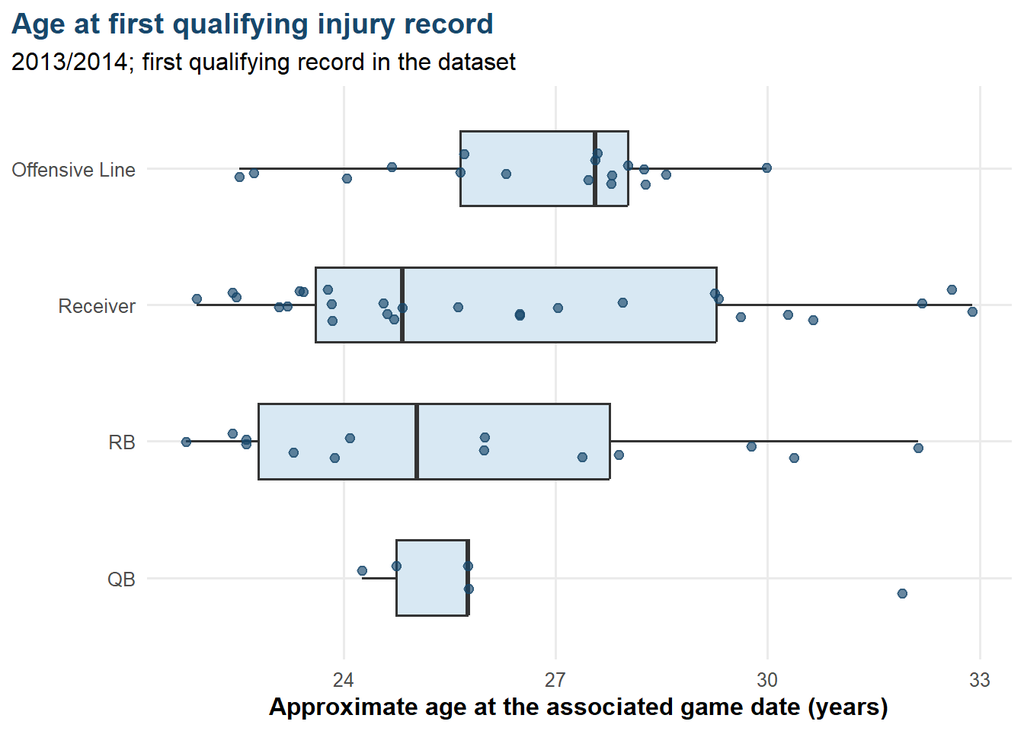

Figure 3: Approximate ages for the 2013/2014 first-qualifying-record cohort.

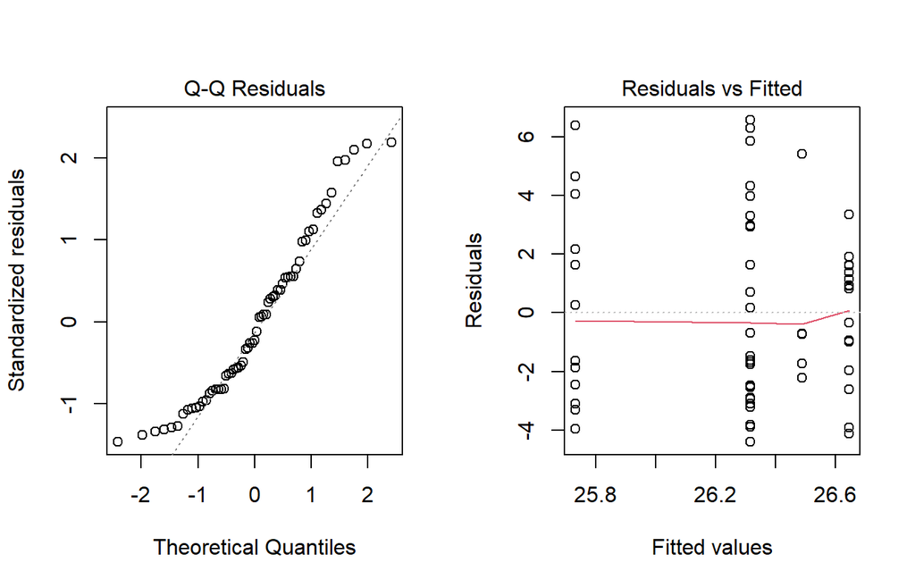

Figure 4: Residual diagnostics for the 2013/2014 extension.

Table 8

| Method | Statistic | p-value |
| --- | --- | --- |
| Classical ANOVA | 0.238 | 0.8694 |
| Welch ANOVA | 0.249 | 0.8607 |
| Kruskal–Wallis | 1.565 | 0.6674 |

Table 9

| Comparison | Difference (years) | Lower simultaneous 95% CI | Upper simultaneous 95% CI | Adjusted p-value |
| --- | --- | --- | --- | --- |
| RB-QB | −0.76 | −4.98 | 3.46 | 0.9645 |
| Receiver-QB | −0.17 | −4.12 | 3.77 | 0.9994 |
| Offensive Line-QB | 0.16 | −3.97 | 4.28 | 0.9996 |
| Receiver-RB | 0.58 | −2.09 | 3.25 | 0.9384 |
| Offensive Line-RB | 0.91 | −2.01 | 3.84 | 0.8424 |
| Offensive Line-Receiver | 0.33 | −2.18 | 2.84 | 0.9855 |

Table 10

| Group | Compared with | Holm-adjusted p-value |
| --- | --- | --- |
| RB | QB | 1.0000 |
| Receiver | QB | 1.0000 |
| Receiver | RB | 1.0000 |
| Offensive Line | QB | 1.0000 |
| Offensive Line | RB | 1.0000 |
| Offensive Line | Receiver | 1.0000 |

There are 63 players, including only 5 quarterbacks. In the Q–Q and group plots, consider possible tail departures and unequal spread; the small quarterback group makes firm distributional judgments difficult. Independence remains a design question rather than a graphical conclusion.

For example, the `RB-QB` mean difference is -0.76 years, with simultaneous 95% interval [-4.98, 3.46]. Describe both the estimate and its uncertainty. At 0.05, classical ANOVA does not reject its null, Welch ANOVA does not reject its null, and Kruskal–Wallis does not reject its null. There are 0 significant Tukey comparisons and 0 significant Holm-adjusted Wilcoxon comparisons at this threshold.

None of these decisions establishes a rule effect. A comparison of p-values across seasons does not test whether the position differences changed. The earliest-eligible-record rule also creates cohorts with different selection histories, and players’ earlier injuries outside the source window are unknown.

# Reproducibility and source notes

- [Concussion Injuries 2012–2014.csv](https://raw.githubusercontent.com/ali-ce/datasets/bab356b2590cbc1f600054f0584509beb2af272d/NFL/Concussion%20Injuries%202012-2014.csv)
- [Head Injured Players.csv](https://raw.githubusercontent.com/ali-ce/datasets/bab356b2590cbc1f600054f0584509beb2af272d/NFL/Head%20Injured%20Players.csv)